# Homework I - Aprendizagem

**Afonso da Conceição Ribeiro**, 102763  
**Miguel Gomes Marques Pessanha de Almeida**, 103493

## I. Pen and Paper [12v]

**Consider the partially learnt decision tree from the dataset *`D`*. *`D`* is described by four input variables – one numeric with values in [0,1] and 3 categorical – and a target variable with three classes.**

### 1) [5v]

**Complete the given decision tree using Information gain with Shannon entropy (log<sub>2</sub>). Consider that: i) a minimum of 4 observations is required to split an internal node, and ii) decisions by ascending alphabetic order should be placed in case of ties.**

There are 7 observations such that y<sub>1</sub> > 0.4.  
We have:

$ \qquad IG(y_{out} \;|\; y_1>0.4, \; y_i) \ = \ H(y_{out} \;|\; y_1>0.4) - H(y_{out} \;|\; y_1>0.4, \; y_i) $

$ \qquad H(y_{out} \;|\; y_1>0.4) \ = \ -\sum_{v\in y_{out}}P(y_{out}=v \;|\; y_1>0.4) \; log_2P(y_{out}=v \;|\; y_1>0.4) \ = \ -(\frac{3}{7} \; log_2\frac{3}{7} + \frac{2}{7} \; log_2\frac{2}{7} + \frac{2}{7} \; log_2\frac{2}{7}) \ = \ 1.5567 $

$ \qquad H(y_{out} \;|\; y_1>0.4, \; y_i) \ = \ \sum_{v\in y_i}P(y_i=v \;|\; y_1>0.4) \; H(y_{out} \;|\; y_1>0.4, \; y_i=v) $

$ \qquad H(y_{out} \;|\; y_1>0.4, \; y_i=z) \ = \ -\sum_{v\in y_{out}}P(y_{out}=v \;|\; y_1>0.4, \; y_i = z) \; log_2P(y_{out}=v \;|\; y_1>0.4, \; y_i = z) $

Therefore, for y<sub>2</sub>:

$ \qquad H(y_{out} \;|\; y_1>0.4, \; y_2=0) \ = \ -(\frac{1}{3} \; log_2\frac{1}{3} + \frac{1}{3} \; log_2\frac{1}{3} + \frac{1}{3} \; log_2\frac{1}{3}) \ = \ 1.5850 $

$ \qquad H(y_{out} \;|\; y_1>0.4, \; y_2=1) \ = \ -(0 + \frac{1}{2} \; log_2\frac{1}{2} + \frac{1}{2} \; log_2\frac{1}{2}) \ = \ 1 $

$ \qquad H(y_{out} \;|\; y_1>0.4, \; y_2=2) \ = \ -(1 \; log_21 + 0 + 0) \ = \ 0 $

$ \qquad H(y_{out} \;|\; y_1>0.4, \; y_2) \ = \ \frac{3}{7} \cdot 1.5850 + \frac{2}{7} \cdot 1 + \frac{2}{7} \cdot 0 \ = \ 0.9650 $

$ \qquad IG(y_{out} \;|\; y_1>0.4, \; y_2) \ = \ 1.5567 - 0.9650 \ = \ 0.5917 $

For y<sub>3</sub>:

$ \qquad H(y_{out} \;|\; y_1>0.4, \; y_3=0) \ = \ -(1 \; log_21 + 0 + 0) \ = \ 0 $

$ \qquad H(y_{out} \;|\; y_1>0.4, \; y_3=1) \ = \ -(\frac{1}{2} \; log_2\frac{1}{2} + \frac{1}{2} \; log_2\frac{1}{2} + 0) \ = \ 1 $

$ \qquad H(y_{out} \;|\; y_1>0.4, \; y_3=2) \ = \ -(\frac{2}{4} \; log_2\frac{2}{4} + 0 + \frac{2}{4} \; log_2\frac{2}{4}) \ = \ 1 $

$ \qquad H(y_{out} \;|\; y_1>0.4, \; y_3) \ = \ \frac{1}{7} \cdot 0 + \frac{2}{7} \cdot 1 + \frac{4}{7} \cdot 1 \ = \ 0.8571 $

$ \qquad IG(y_{out} \;|\; y_1>0.4, \; y_3) \ = \ 1.5567 - 0.8571 \ = \ 0.6996 $

And for y<sub>4</sub>:

$ \qquad H(y_{out} \;|\; y_1>0.4, \; y_4=0) \ = \ -(\frac{1}{2} \; log_2\frac{1}{2} + 0 + \frac{1}{2} \; log_2\frac{1}{2}) \ = \ 1 $

$ \qquad H(y_{out} \;|\; y_1>0.4, \; y_4=1) \ = \ -(\frac{1}{3} \; log_2\frac{1}{3} + \frac{2}{3} \; log_2\frac{2}{3} + 0) \ = \ 0.9183 $

$ \qquad H(y_{out} \;|\; y_1>0.4, \; y_4=2) \ = \ -(\frac{1}{2} \; log_2\frac{1}{2} + 0 + \frac{1}{2} \; log_2\frac{1}{2}) \ = \ 1 $

$ \qquad H(y_{out} \;|\; y_1>0.4, \; y_4) \ = \ \frac{2}{7} \cdot 1 + \frac{3}{7} \cdot 0.9183 + \frac{2}{7} \cdot 1 \ = \ 0.9650 $

$ \qquad IG(y_{out} \;|\; y_1>0.4, \; y_4) \ = \ 1.5567 - 0.9650 \ = \ 0.5917 $

The variable with the highest Information Gain is y<sub>3</sub>, so it is the one chosen to do the split.  
For y<sub>3</sub> = 0, we have y<sub>out</sub> = B.  
For y<sub>3</sub> = 1, we have two observations, one with y<sub>out</sub> = A and another one with y<sub>out</sub> = B, so we follow the alphabetical order and decide y<sub>out</sub> = A.  
For y<sub>3</sub> = 2, we have four observations, two with y<sub>out</sub> = A and two with y<sub>out</sub> = C, so we do another split:

$ \qquad H(y_{out} \;|\; y_1>0.4, \; y_3=2) \ = \ -(\frac{2}{4} \; log_2\frac{2}{4} + 0 + \frac{2}{4} \; log_2\frac{2}{4}) \ = \ 1 $

Therefore, for y<sub>2</sub>:

$ \qquad H(y_{out} \;|\; y_1>0.4, \; y_3=2, \; y_2=0) \ = \ -(0 + 0 + 1 \; log_21) \ = \ 0 $

$ \qquad H(y_{out} \;|\; y_1>0.4, \; y_3=2, \; y_2=1) \ = \ -(0 + 0 + 1 \; log_21) \ = \ 0 $

$ \qquad H(y_{out} \;|\; y_1>0.4, \; y_3=2, \; y_2=2) \ = \ -(\frac{2}{2} \; log_2\frac{2}{2} + 0 + 0) \ = \ 0 $

$ \qquad H(y_{out} \;|\; y_1>0.4, \; y_3=2, \; y_2) \ = \ \frac{1}{4} \cdot 0 + \frac{1}{4} \cdot 0 + \frac{2}{4} \cdot 0 \ = \ 0 $

$ \qquad IG(y_{out} \;|\; y_1>0.4, \; y_3=2, \; y_2) \ = \ 1 - 0 \ = \ 1 $

And for y<sub>4</sub>:

$ \qquad H(y_{out} \;|\; y_1>0.4, \; y_3=2, \; y_4=0) \ = \ -(\frac{1}{2} \; log_2\frac{1}{2} + 0 + \frac{1}{2} \; log_2\frac{1}{2}) \ = \ 1 $

$ \qquad H(y_{out} \;|\; y_1>0.4, \; y_3=2, \; y_4=1) \ = \ -(1 \; log_21 + 0 + 0) \ = \ 0 $

$ \qquad H(y_{out} \;|\; y_1>0.4, \; y_3=2, \; y_4=2) \ = \ -(0 + 0 + 1 \; log_21) \ = \ 0 $

$ \qquad H(y_{out} \;|\; y_1>0.4, \; y_3=2, \; y_4) \ = \ \frac{2}{4} \cdot 1 + \frac{1}{4} \cdot 0 + \frac{1}{4} \cdot 0 \ = \ 0.5 $

$ \qquad IG(y_{out} \;|\; y_1>0.4, \; y_3=2, \; y_4) \ = \ 1 - 0.5 \ = \ 0.5 $

The variable with the highest Information Gain is y<sub>2</sub>, so it is the one chosen to do the split.  
For y<sub>2</sub> = 0, we have y<sub>out</sub> = C.  
For y<sub>2</sub> = 1, we have y<sub>out</sub> = C.  
For y<sub>2</sub> = 2, we have y<sub>out</sub> = A.

The complete decision tree is the following:

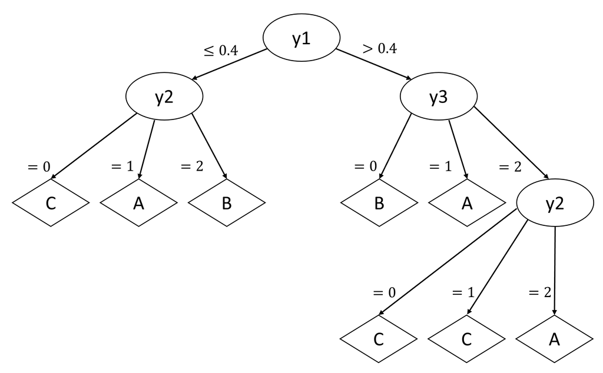

### 2) [2.5v]

**Draw the training confusion matrix for the learnt decision tree.**

|  |  | Ground Truth |  |  |  |  |
| --- | --- | --- | --- | --- | --- | --- |
|  |  | A | B | C |  |  |
| Prediction | A | 4 | 1 | 0 |  | 5 |
|  | B | 0 | 2 | 0 | 2 |  |
|  | C | 0 | 1 | 4 | 5 |  |
|  |  | 4 | 4 | 4 | 12 |  |

### 3) [1.5v]

**Identify which class has the lowest training F1 score.**

$ \qquad \beta = 1 \qquad \alpha = \frac{1}{1 + \beta^2} = 0.5 $

$ \qquad F_1 \ = \ \frac{1}{\alpha \cdot \frac{1}{p} + (1 - \alpha) \cdot \frac{1}{p}} \ = \ \frac{2}{\frac{1}{p} + \frac{1}{p}} $

$ \qquad precision_{class} = \frac{TP_{class}}{TP_{class} + FP_{class}} $

$ \qquad recall_{class} = \frac{TP_{class}}{TP_{class} + FN_{class}} $

Class A:

$ \qquad precision_A = \frac{4}{4 + 1} = 0.8 $

$ \qquad recall_A = \frac{4}{4 + 0} = 1 $

$ \qquad F_{1_A} = \frac{2}{\frac{1}{0.8} + \frac{1}{1}} = \frac{8}{9} $

Class B:

$ \qquad precision_B = \frac{2}{2 + 0} = 1 $

$ \qquad recall_B = \frac{2}{2 + 2} = 0.5 $

$ \qquad F_{1_B} = \frac{2}{\frac{1}{1} + \frac{1}{0.5}} = \frac{2}{3} $

Class C:

$ \qquad precision_C = \frac{4}{4 + 1} = 0.8 $

$ \qquad recall_C = \frac{4}{4 + 0} = 1 $

$ \qquad F_{1_C} = \frac{2}{\frac{1}{0.8} + \frac{1}{1}} = \frac{8}{9} $

The class with the lowest training F1 score is class B.

### 4) [1v]

**Considering `y`<sub>`2`</sub> to be ordinal, assess if `y`<sub>`1`</sub> and `y`<sub>`2`</sub> are correlated using the Spearman coefficient.**

$$ Spearman(y_1, y_2) \ = \ Pearson(rank \, y_1, rank \, y_2) \ = \ \frac{Cov(rank \, y_1, rank \, y_2)}{\sqrt{Var(rank \, y_1) \; Var(rank \, y_2)}} $$

| D | y<sub>1</sub> | y<sub>2</sub> | rank y<sub>1</sub> | rank y<sub>2</sub> |
| --- | --- | --- | --- | --- |
| **x<sub>1</sub>** | 0.24 | 1 | 3 | 8 |
| **x<sub>2</sub>** | 0.06 | 2 | 2 | 11 |
| **x<sub>3</sub>** | 0.04 | 0 | 1 | 3.5 |
| **x<sub>4</sub>** | 0.36 | 0 | 5 | 3.5 |
| **x<sub>5</sub>** | 0.32 | 0 | 4 | 3.5 |
| **x<sub>6</sub>** | 0.68 | 2 | 10 | 11 |
| **x<sub>7</sub>** | 0.90 | 0 | 12 | 3.5 |
| **x<sub>8</sub>** | 0.76 | 2 | 11 | 11 |
| **x<sub>9</sub>** | 0.46 | 1 | 7 | 8 |
| **x<sub>10</sub>** | 0.62 | 0 | 9 | 3.5 |
| **x<sub>11</sub>** | 0.44 | 1 | 6 | 8 |
| **x<sub>12</sub>** | 0.52 | 0 | 8 | 3.5 |

$ Cov(rank \, y_1, rank \, y_2) \ = \ \frac{1}{12 - 1} \sum_{i=1}^{12} (rank \, y_{1_i} - \overline{rank \, y_1}) \cdot (rank \, y_{2_i} - \overline{rank \, y_2}) \ = \ 0.9545455 $

$ Var(rank \, y_1) \ = \ \frac{1}{12 - 1} \sum_{i=1}^{12} (rank \, y_{1_i} - \overline{rank \, y_1})^2 \ = \ 13 $

$ Var(rank \, y_2) \ = \ \frac{1}{12 - 1} \sum_{i=1}^{12} (rank \, y_{2_i} - \overline{rank \, y_2})^2 \ = \ 11.0454545 $

$ Spearman(y_1, y_2) \ = \ \frac{0.9545455}{\sqrt{13 \; \cdot \; 11.0454545}} \ = \ 0.0796587 $

Therefore, y<sub>1</sub> and y<sub>2</sub> are not correlated.

### 5) [1v]

Draw the class-conditional relative histograms of `y`<sub>`1`</sub> using 5 equally spaced bins in [0,1].  
Challenge: find the root split using the discriminant rules from these empirical distributions.

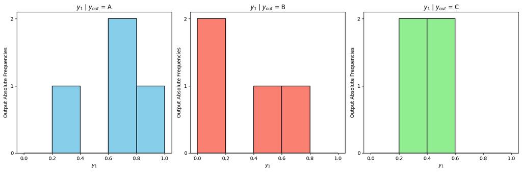

```python
import numpy as np
import matplotlib.pyplot as plt

# Define the bin edges for all graphics
bin_edges = [0, 0.2, 0.4, 0.6, 0.8, 1]

# Data for graphic A
data_a_values = [0, 1, 0, 2, 1] # Corresponding values for each bin

# Data for graphic B
data_b_values = [2, 0, 1, 1, 0] # Corresponding values for each bin

# Data for graphic C
data_c_values = [0, 2, 2, 0, 0] # Corresponding values for each bin

# Create subplots
fig, axes = plt.subplots(1, 3, figsize=(15, 5))

# Plot graphic A
axes[0].bar(bin_edges[:-1], data_a_values, width=0.2, color='skyblue', align='edge', edgecolor='black', linewidth=1.2)
axes[0].set_title('$y_1$ | $y_{out}$ = A')
axes[0].set_xlabel('$y_1$')
axes[0].set_ylabel('Output Absolute Frequencies')
axes[0].set_yticks(np.arange(0, max(data_a_values) + 1, 1))

# Plot graphic B
axes[1].bar(bin_edges[:-1], data_b_values, width=0.2, color='salmon', align='edge', edgecolor='black', linewidth=1.2)
axes[1].set_title('$y_1$ | $y_{out}$ = B')
axes[1].set_xlabel('$y_1$')
axes[1].set_ylabel('Output Absolute Frequencies')
axes[1].set_yticks(np.arange(0, max(data_b_values) + 1, 1))

# Plot graphic C
axes[2].bar(bin_edges[:-1], data_c_values, width=0.2, color='lightgreen', align='edge', edgecolor='black', linewidth=1.2)
axes[2].set_title('$y_1$ | $y_{out}$ = C')
axes[2].set_xlabel('$y_1$')
axes[2].set_ylabel('Output Absolute Frequencies')
axes[2].set_yticks(np.arange(0, max(data_c_values) + 1, 1))

# Adjust layout
plt.tight_layout()

# Show the plots
plt.show()
```

According to the obtained class-conditional distribution, the root split of y<sub>1</sub> would result in the thresholds $[0; 0.2[$ , $[0.2; 0.6[$ and $[0.6; 1.0[$, as these are the intervals in which the highest frequencies of each output class are observed.

## II. Programming [9v]

To answer the following questions, consider using the `sklearn` API documentation and the notebooks in the course webpage as guidance. Show in your PDF report both the code and the corresponding results.  
Consider the `column_diagnosis.arff` data available at the homework tab, comprising 6 biomechanical features to classify 310 orthopaedic patients into 3 classes (normal, disk hernia, spondilolysthesis).

```python
# Import Libraries
import pandas as pd
import numpy as np
import matplotlib.pyplot as plt

import seaborn as sns
from scipy.io.arff import loadarff
from sklearn import feature_selection, model_selection, tree, metrics
```

```python
# Data Loading
data = loadarff("./column_diagnosis.arff")
df = pd.DataFrame(data[0])
df["class"] = df["class"].str.decode("utf-8")

# Data Preprocessing
X = df.drop("class", axis=1)
y = df["class"]
```

### 1) [1.5v]

Apply `f_classif` from `sklearn` to assess the discriminative power of the input variables. Identify the input variable with the highest and lowest discriminative power.  
Plot the class-conditional probability density functions of these two input variables.

```
Variable with the Highest Discriminative Power:	 degree_spondylolisthesis
Variable with the Lowest Discriminative Power:	 pelvic_radius
```

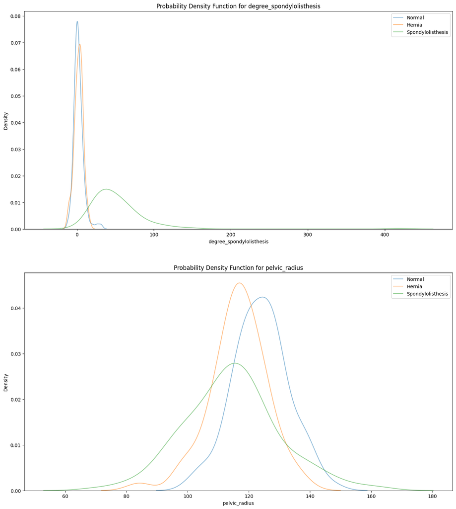

```python
# Calculate F-values using f_classif
F_values = feature_selection.f_classif(X, y)[0]

# Identify the input variable with the highest and lowest discriminative power
max_F_index = np.argmax(F_values)
print("Variable with the Highest Discriminative Power:\t", X.columns.values[max_F_index])
min_F_index = np.argmin(F_values)
print("Variable with the Lowest Discriminative Power:\t", X.columns.values[min_F_index])

# Create subplots
fig, axes = plt.subplots(2, 1, figsize=(16, 18))

# Plot class-conditional probability density functions
sns.kdeplot(X.iloc[:, max_F_index][y == "Normal"], label="Normal", ax=axes[0], alpha=0.5)
sns.kdeplot(X.iloc[:, max_F_index][y == "Hernia"], label="Hernia", ax=axes[0], alpha=0.5)
sns.kdeplot(X.iloc[:, max_F_index][y == "Spondylolisthesis"], label="Spondylolisthesis", ax=axes[0], alpha=0.5)
axes[0].set_title("Probability Density Function for degree_spondylolisthesis")

sns.kdeplot(X.iloc[:, min_F_index][y == "Normal"], label="Normal", ax=axes[1], alpha=0.5)
sns.kdeplot(X.iloc[:, min_F_index][y == "Hernia"], label="Hernia", ax=axes[1], alpha=0.5)
sns.kdeplot(X.iloc[:, min_F_index][y == "Spondylolisthesis"], label="Spondylolisthesis", ax=axes[1], alpha=0.5)
axes[1].set_title("Probability Density Function for pelvic_radius")

# Add legends
axes[0].legend()
axes[1].legend()

# Show the plots
plt.show()
```

### 2) [4v]

Using a stratified 70-30 training-testing split with a fixed seed (`random_state=0`), assess in a single plot both the training and testing accuracies of a decision tree with depth limits in {1,2,3,4,5,6,8,10} and the remaining parameters as default.  
*[optional]* Note that split thresholding of numeric variables in decision trees is non-deterministic in `sklearn`, hence you may opt to average the results using 10 runs per parameterization.

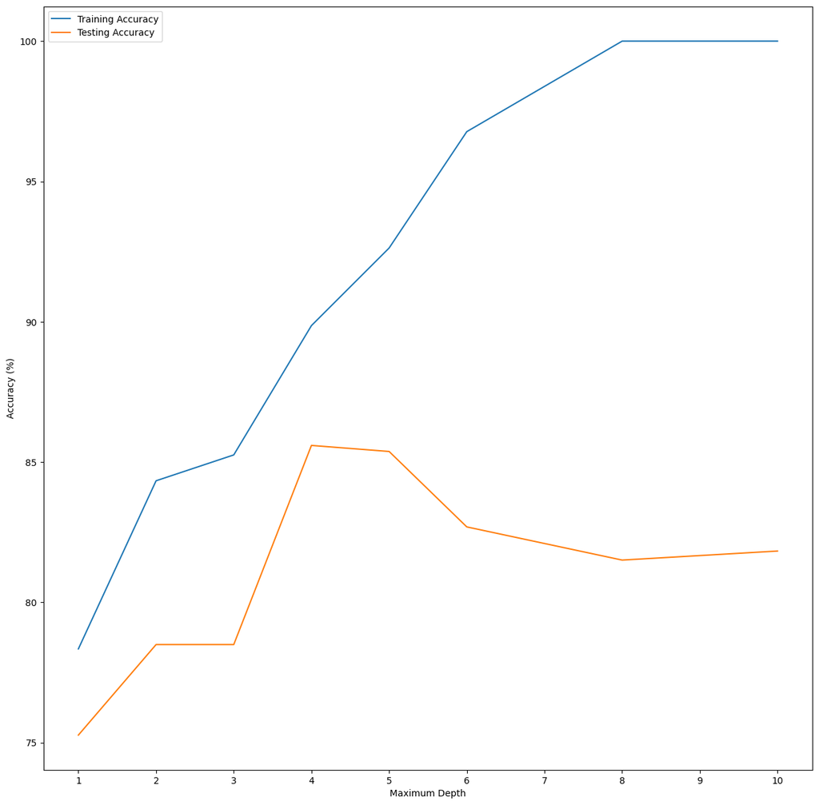

```python
# Split the dataset into a training set (70%) and a testing set (30%),
# using stratified sampling
X_train, X_test, y_train, y_test = \
    model_selection.train_test_split(X, y, train_size=0.7, \
    stratify=y, random_state=0)

depth_limits = [1, 2, 3, 4, 5, 6, 8, 10]

training_acc = []
testing_acc = []

# Averaging results over 10 runs per parameterization
num_runs = 10

for i in depth_limits:
    train_acc_sum = 0
    test_acc_sum = 0
    for _ in range(num_runs):
        clf = tree.DecisionTreeClassifier(max_depth=i)
        clf.fit(X_train, y_train)
        y_pred_train = clf.predict(X_train)
        y_pred_test = clf.predict(X_test)
        train_acc_sum += metrics.accuracy_score(y_train, y_pred_train)
        test_acc_sum += metrics.accuracy_score(y_test, y_pred_test)
    training_acc.append(train_acc_sum / num_runs)
    testing_acc.append(test_acc_sum / num_runs)

# Multiply the accuracy scores by 100 to convert them to percentages
training_acc = [acc * 100 for acc in training_acc]
testing_acc = [acc * 100 for acc in testing_acc]

plt.figure(figsize = (15, 15))
plt.plot(depth_limits, training_acc, label="Training Accuracy")
plt.plot(depth_limits, testing_acc, label="Testing Accuracy")
plt.xticks(range(1, 11))
plt.xlabel("Maximum Depth")
plt.ylabel("Accuracy (%)")
plt.legend()
plt.show()
```

### 3) [1.5v]

**Comment on the results, including the generalization capacity across settings.**

The results show that as the maximum depth of the decision tree increases, training accuracy improves significantly.

However, testing accuracy plateaus and then decreases beyond a certain depth. This suggests that the model has high capacity to fit the training data but lacks generalization capacity, performing worse on unseen data with overly deep trees. The optimal maximum depth balances model complexity and generalization.

The training accuracy consistently increases as the maximum depth of the decision tree grows. This occurs because deeper trees can capture more details and noise within the training data, resulting in a better fit. Training accuracy reaches 100% with high maximum depths, indicating that the model effectively memorizes the training data. However, extremely high training accuracy doesn't necessarily translate to good generalization, as the model may struggle to perform well on new, unseen data due to overfitting.

### 4) [2v]

**To deploy the predictor, a healthcare team opted to learn a single decision tree (`random_state=0`) using *all* available data as training data, and further ensuring that each leaf has a minimum of 20 individuals in order to avoid overfitting risks.**

#### i.

**Plot the decision tree.**

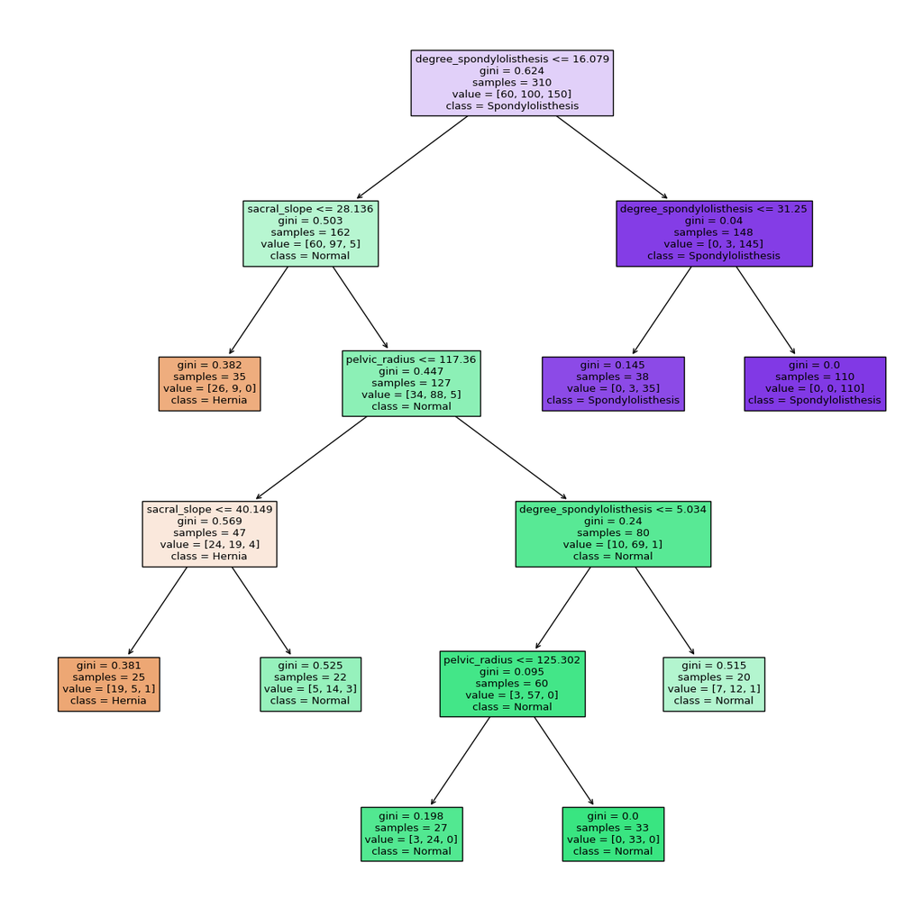

```python
clf = tree.DecisionTreeClassifier(random_state = 0, min_samples_leaf = 20)
clf.fit(X, y)

plt.figure(figsize = (15, 15))
tree.plot_tree(clf, feature_names = X.columns.values, class_names = clf.classes_, filled = True)
plt.show()

# gini: measure of impurity or disorder in a node.
# It quantifies the likelihood of misclassifying a randomly chosen element if it
# was randomly classified according to the distribution of samples in the node.
```

#### ii.

**Characterize a hernia condition by identifying the hernia-conditional associations.**

Based on the plotted decision tree, a hernia condition is identified with the highest probability when one of the following sets of predicates is true:

- degree_spondylolisthesis $\leq$ 16.079 $\quad \land \quad$ sacral_slope $\leq$ 28.136
- degree_spondylolisthesis $\leq$ 16.079 $\quad \land \quad$ 28.136 $<$ sacral_slope $\leq$ 40.149 $\quad \land \quad$ pelvic_radius $\leq$ 117.36